# ¿Qué pasajeros sobrevivirán al naufragio del RMS Titanic?

Ejercicio Práctico Minería y Análisis de Datos

RG

14/09/2022

## 1) Lectura de los datos.

Para esta práctica utilizaremos el archivo TITANIC.CSV. La base incluye información relevante para describir el estado de supervivencia y datos particulares de los pasajeros del RMS Titanic (no contiene información de la tripulación). La fuente principal de los datos es la Enciclopedia Titanica y contiene las aportaciones de varios investigadores.

```r
datos <- read.csv("./data/titanic.csv")
datos <- as.data.frame(datos)
#View(datos)
```

Las variables con las que trabajaremos a lo largo de este documento son las siguientes

- *Name*: Nombre del pasajero.
- *Survived*: Dummy que indica si sobrevivió (1) o no sobrevivió (0).
- *Pclass*:Tipo de clase en la que viajó (1=1st; 2=2nd; 3=3rd).
- *Age*: Edad del pasajero.
- *Sex*: Sexo del pasajero.
- *Fare*: Tarifa que pagó el pasajero.
- *Siblings_Spouses*: Indica el número de hermanos y/o cónyuges que lo acompañaron.
- *Parents_Children*:Indica el número de padres y/o hijos que lo acompañaron.

Se crearon ademas dos variables:

- *Fare_grps*: Indicadora de si el pasajero gasto menos de 60 libras o más de 60 libras en el boleto.
- *Family_size*: Numero de integrantes de la familia del pasajero. Se construyó con la suma de de las variables Siblings_Spouses y Parents_Children. Cuando su valor es igual a cero implica que el individuo viajó sin familiares directos.

## 2) Relaciones esperadas.

Empezaremos por explorar los valores de las correlaciones de las variables. Para ello elaboraremos un gráfico con la información.

### Matriz de Correlaciones

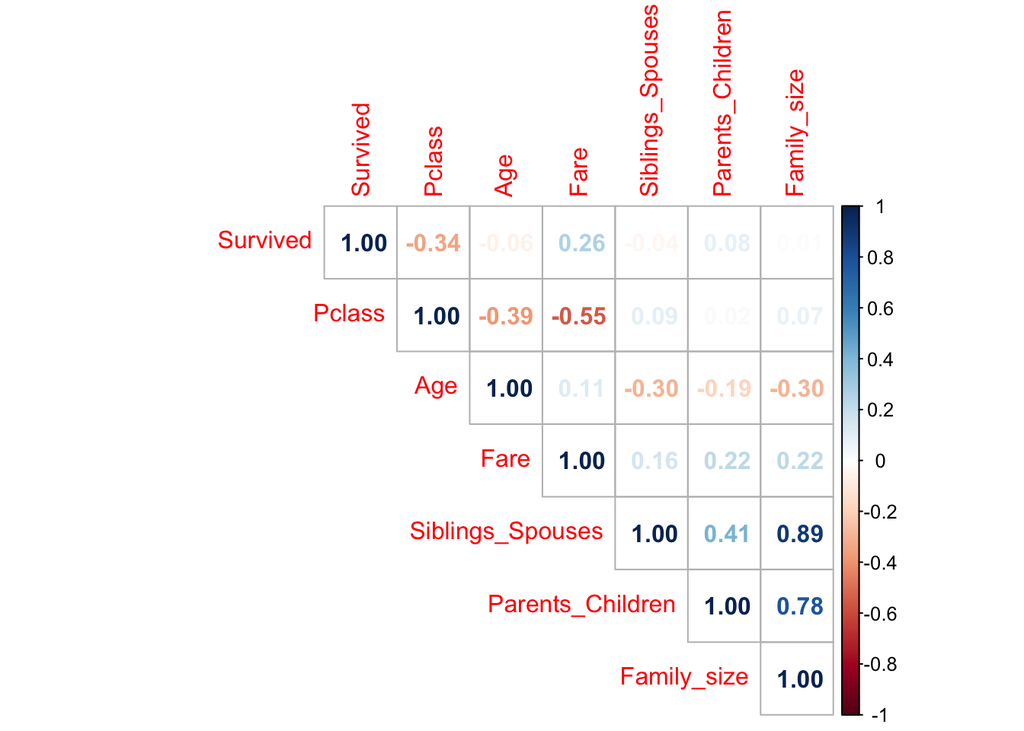

### Análisis Gráfico

Nos enfocaremos en entender la distribución y las diferentes características de nuestros datos mediante un análisis gráfico de algunas de las variables.

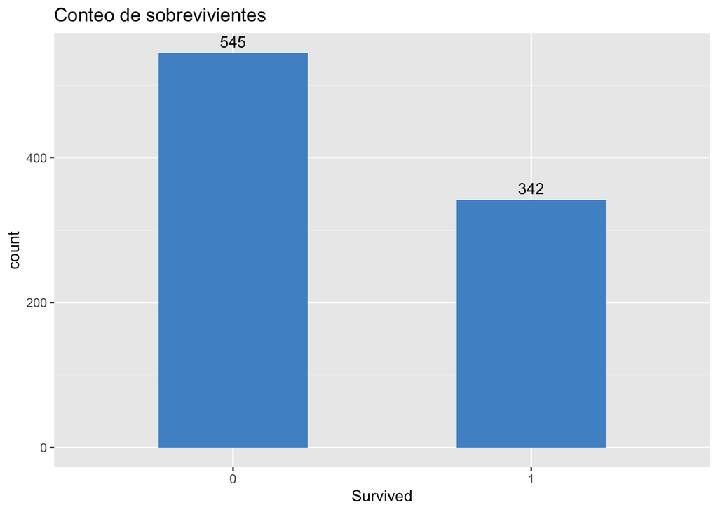

Podemos observar que de los 887 pasajeros de los cuales tenemos información únicamente 342 de ellos sobrevivieron. Lamentablemente poco más del 60% de los pasajeros falleció.

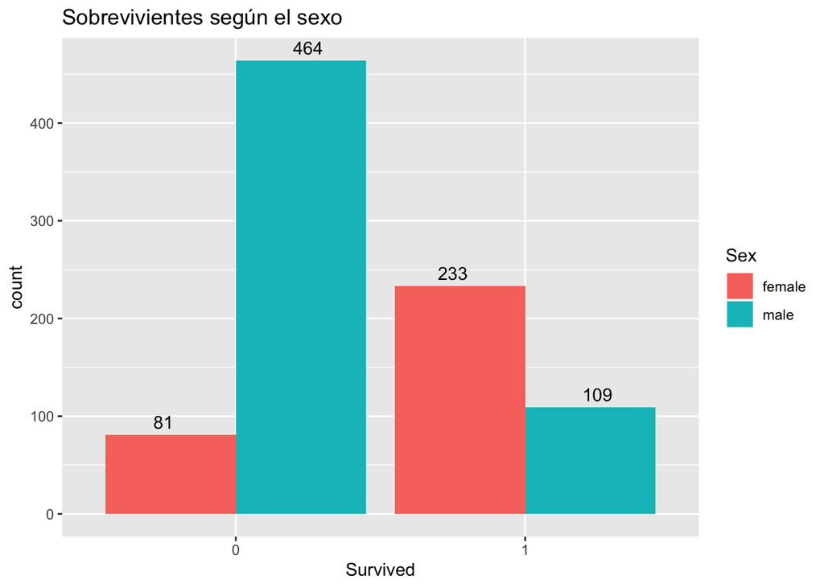

Para tener una mejor idea de lo que sucedió tras el accidente del Titanic en la gráfica anterior volvemos a concentrarnos en el numero de sobrevivientes, pero considerando el sexo. Como podemos observar, de los 342 pasajeros que sobrevivieron, 233 (alrededor del 68%) fueron mujeres y 109 fueron hombres. En el caso de los pasajeros que no sobrevivieron 464 (cerca del 85% del total) eran hombres.

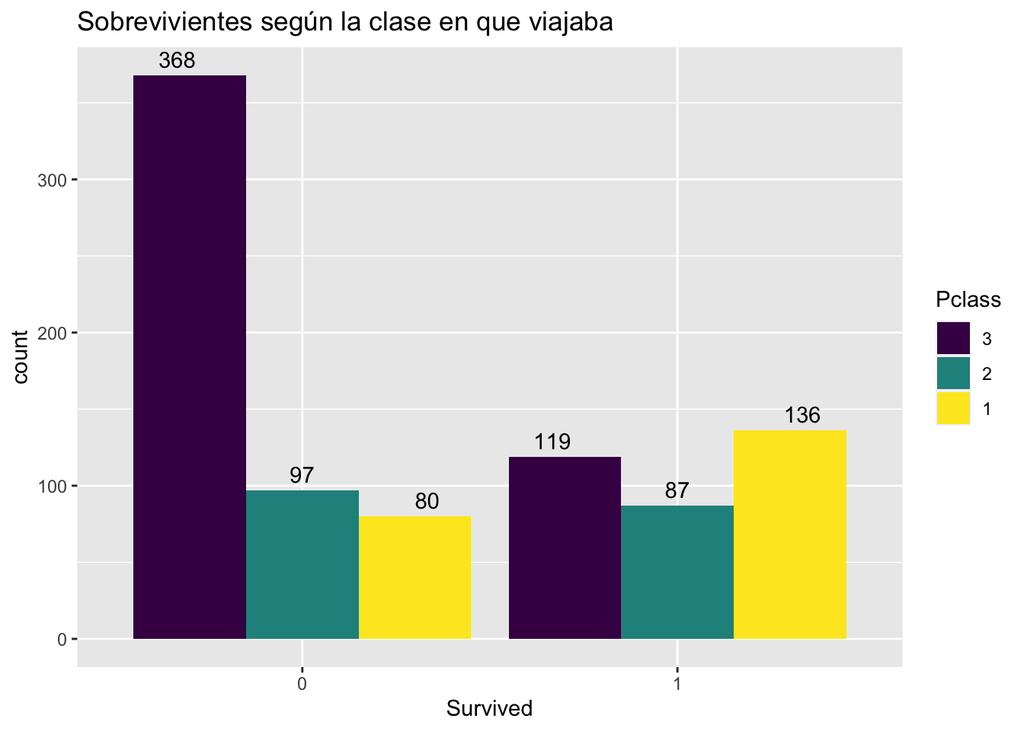

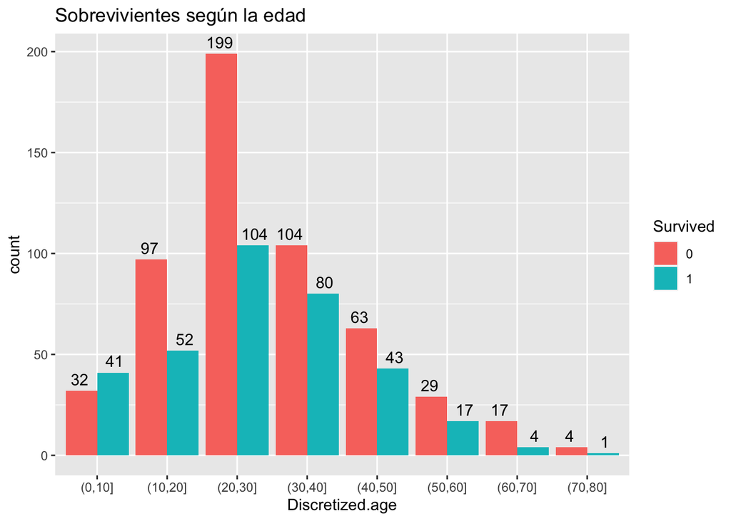

Otro aspecto importante del problema es comprender como el suceso afectó a los diferentes grupos de edad. Podemos observar que la mayor cantidad tanto de sobrevivientes como de no sobrevivientes está entre los grupos de 10 a 40 años.

Para entender mejor los resultados del gráfico anterior presentamos el histograma de las edades de los pasajeros.

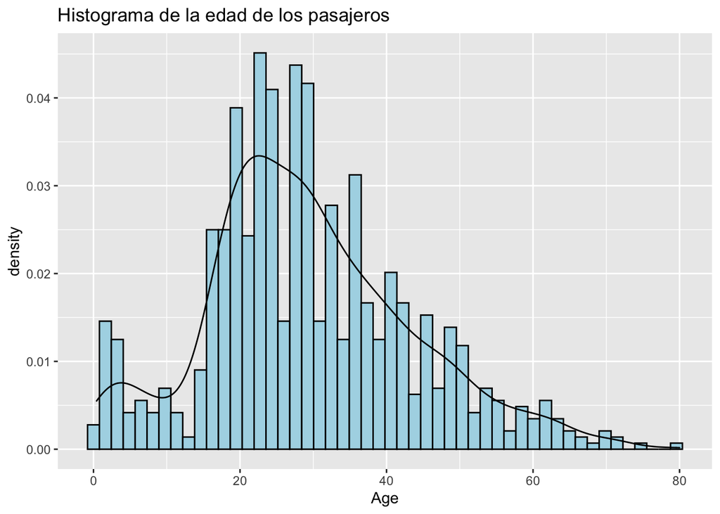

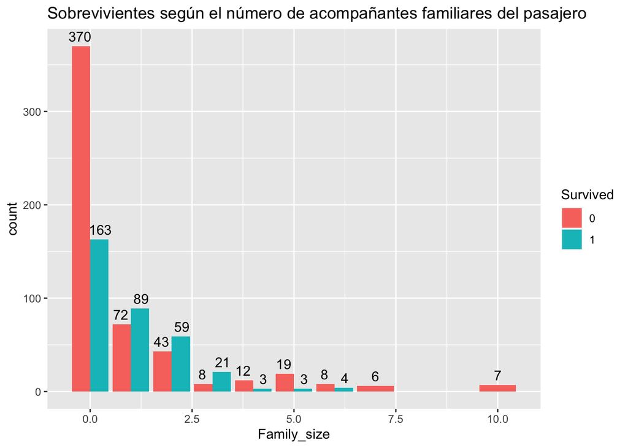

Un punto importante al viajar es saber si se realizó sólo o acompañado. Para analizar este punto consideramos la información de la variable que construimos respecto al tamaño de la familia. Los datos nos muestran que aquellos que viajaban solos (0 en tamaño de la familia) fueron el grupo que concentro el mayor numero de pasajeros que no sobrevivieron.

Nuevamente presentamos el histograma del tamaño de las familias de los pasajeros para enriquecer la interpretación de los resultados del gráfico anterior.

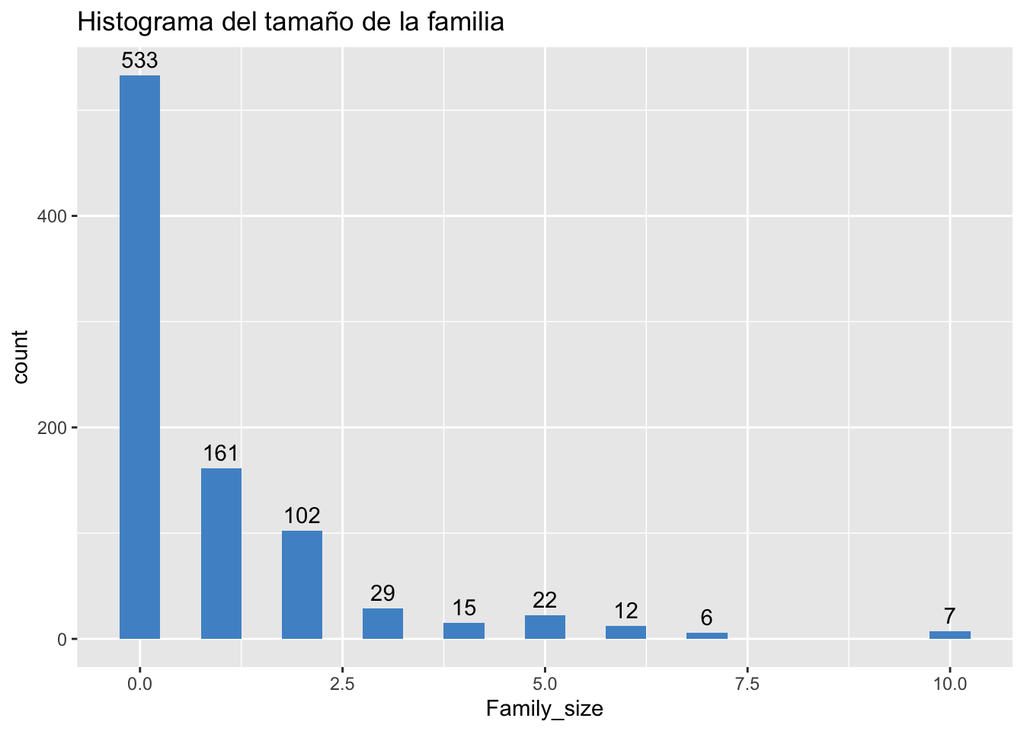

Por último, respecto de las variables con las que contamos es importante comprender el histograma de la tarifa que cubrieron cada uno de los pasajeros. Dado que el tipo de clase en la que se viajaba fue un determinante importante de la probabilidad de no sobrevivir, esto nos ayudará a entender el gasto por boleto que se realizó.

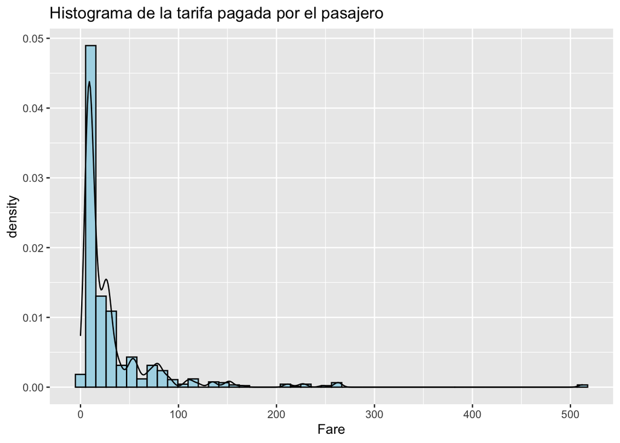

La variable *Fare_grps* se creo pensando en que un boleto que costará mas de 60 libras incorporaría la información de los pasajeros con más recursos. Lo anterior sin importar si se encontraba en primera o segunda clase.

### Algunos Gráficos Adicionales

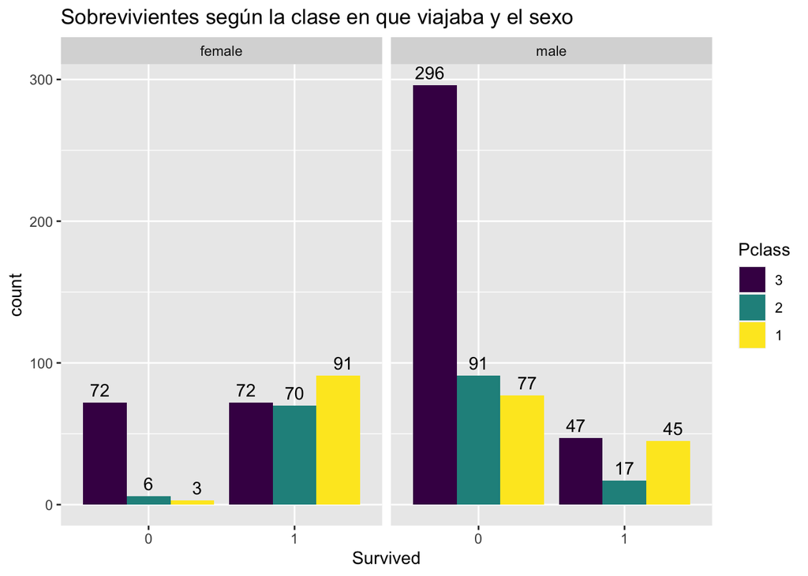

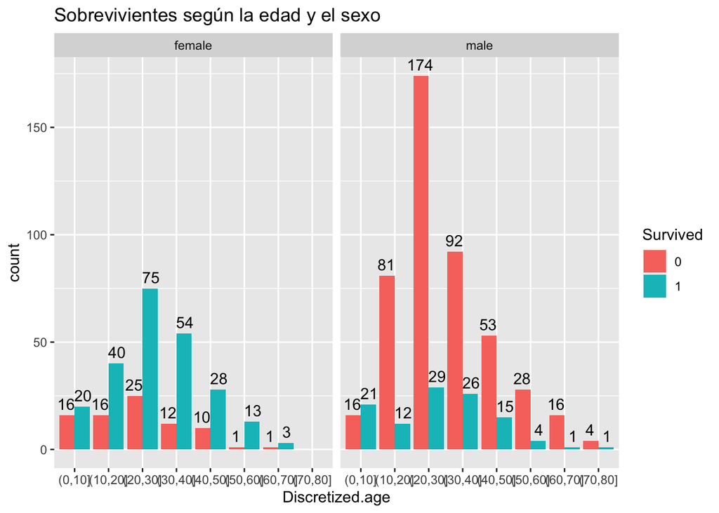

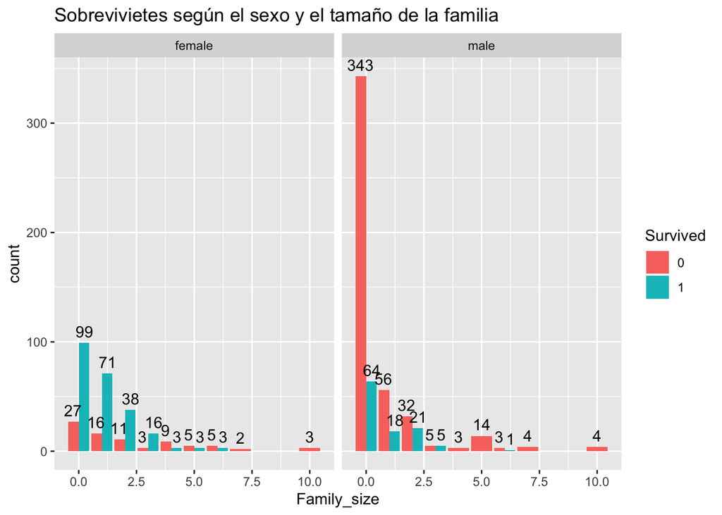

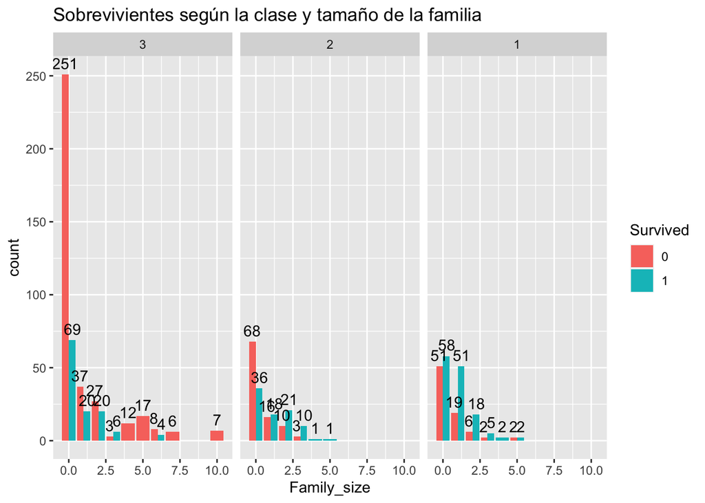

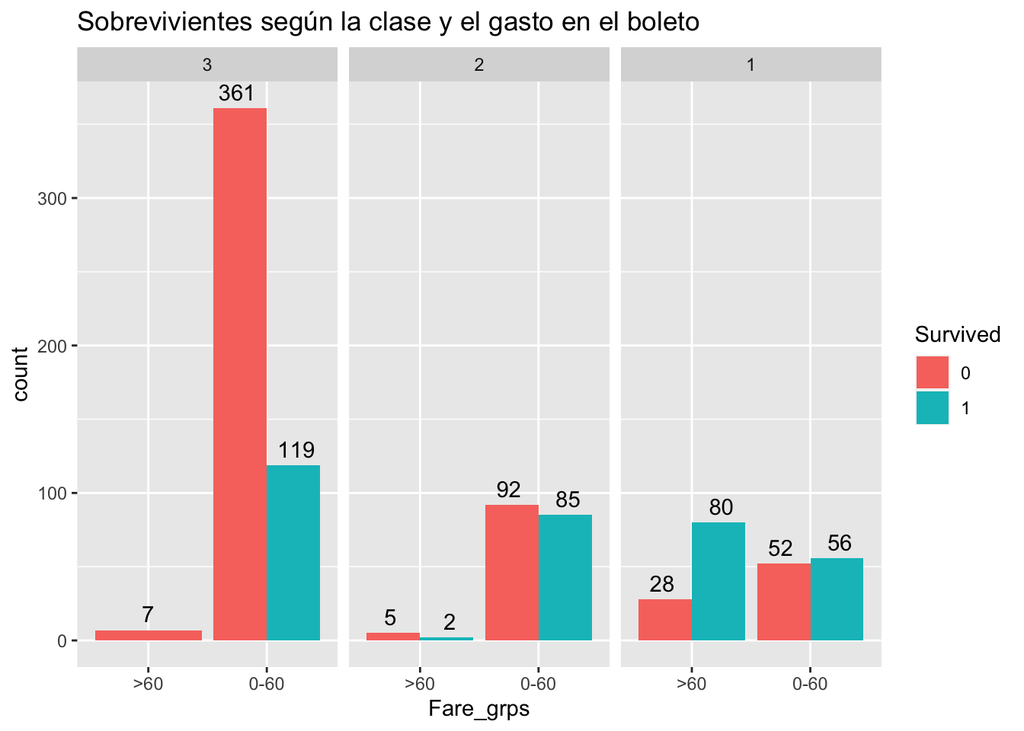

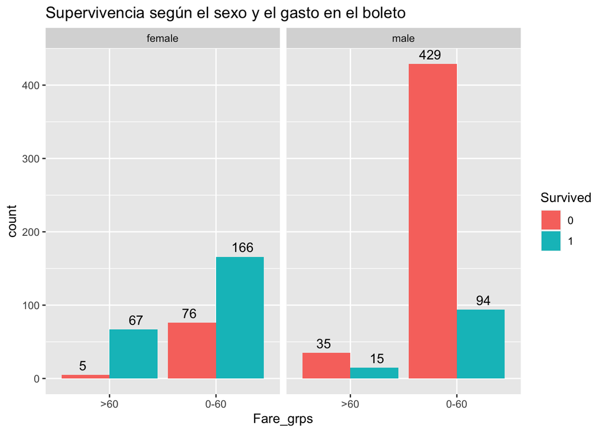

## 3) Estimación del modelo.

### Probabilidad de Sobrevivir - Modelo Logit

En primer lugar nos interesa entender que determinó la probabilidad de sobrevivir. Para estimar un modelo que nos ayude a comprender este dilema utilizaremos varios modelos Logit. La diferencia entre cada una de las especificaciones será el tipo de variables que agreguemos.

De las variables que analizamos en la sección anterior elegimos como base incorporar *Pclass, Sex, Age*. Los diferentes modelos que especificamos para el logit tendrán como diferencia como tratamos las variables *Fare, Siblings_Spouses, Parents_Children*.

En cuanto a la variable *Fare*, algunos modelos la consideraran tal como está reportada en la base de datos y en otros utilizaremos *Fare_grps*. Esta última variable se incorpora pensando que el gasto en el boleto pudo tener ciertos rangos al considerar las características de cada pasajero. La intención es ver cual variable resulta mejor.

Respecto las variables Siblings_Spouses, Parents_Children y Family_size, en algunas especificaciones buscaremos ver si el modelo responde mejor al numero total de integrantes de la familia en comparación contra la separación que tenia la base con las variables Siblings_Spouses y Parents_Children.

*Separando entre clases*

### Diferencias entre clases de viaje - Modelo Logit Ordenado

Un segundo análisis que elaboraremos será entorno a la clase en la que los pasajeros viajaban. Para esta sección utilizaremos un logit ordenado para poder entender las diferencias entre clases. Al igual que en el punto anterior la diferencia entre cada una de las especificaciones será el tipo de variables que agreguemos.

## 4) Apéndice Tablas

Modelos logit sin transformar los valores de los coeficientes.

### *Probabilidad de sobrevivir*